# Carte des variables environnementales finales

## Illustration des variables

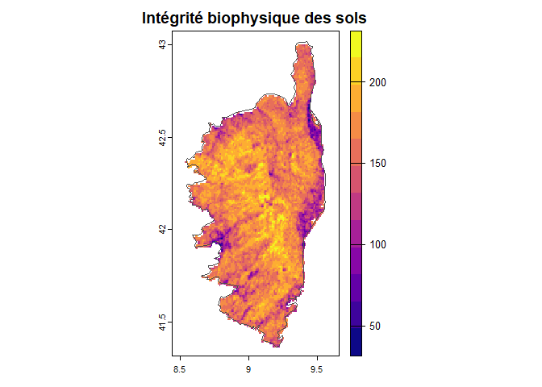

```r
plot(env_corse[["integrite"]],
     col = viridis::plasma(12),
     main = "Intégrité biophysique des sols")
plot(st_geometry(fra), add = TRUE,
     border = grey(0.3))
```

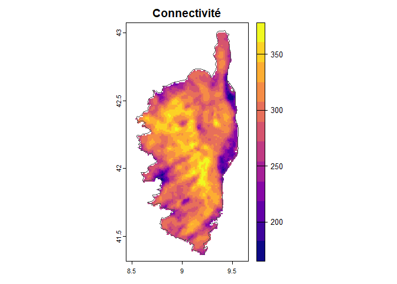

```r
plot(env_corse[["connectivite"]],
     col = viridis::plasma(12),
     main = "Connectivité")
plot(st_geometry(fra), add = TRUE,
     border = grey(0.3))
```

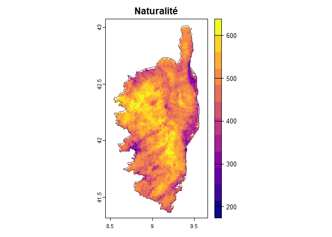

```r
plot(env_corse[["naturalite"]],
     col = viridis::plasma(12),
     main = "Naturalité")
plot(st_geometry(fra), add = TRUE,
     border = grey(0.3))
```

# 8. Densité de population humaine

## Description et méta-données

**Téléchargement :** https://sedac.ciesin.columbia.edu/data/set/popdynamics-1-km-downscaled-pop-base-year-projection-ssp-2000-2100-rev01/data-download

**Intervalle temporel :** 2000

**Type de données :** raster

**Résolution initiale :** 0.008333 * 0.008333 °

**Méta-données :** https://sedac.ciesin.columbia.edu/data/set/popdynamics-1-km-downscaled-pop-base-year-projection-ssp-2000-2100-rev01/metadata

**Références bibliographiques :** - Gao, J. 2020. Global 1-km Downscaled Population Base Year and Projection Grids Based on the Shared Socioeconomic Pathways, Revision 01. Palisades, New York: NASA Socioeconomic Data and Applications Center (SEDAC). https://doi.org/10.7927/q7z9-9r69.

- Gao, J. 2017. Downscaling Global Spatial Population Projections from 1/8-degree to 1-km Grid Cells. NCAR Technical Note NCAR/TN-537+STR. https://doi.org/10.5065/D60Z721H.

**Licence :** Licence libre type CC-BY

**Description des variables :** Densité de population humaine dans chaque cellule. Les données ont été transformées en log10 ($log(x + 1)$), car la densité de population humaine très faible en Corse créait une variable à distribution trop asymétrique.

## Illustration des variables

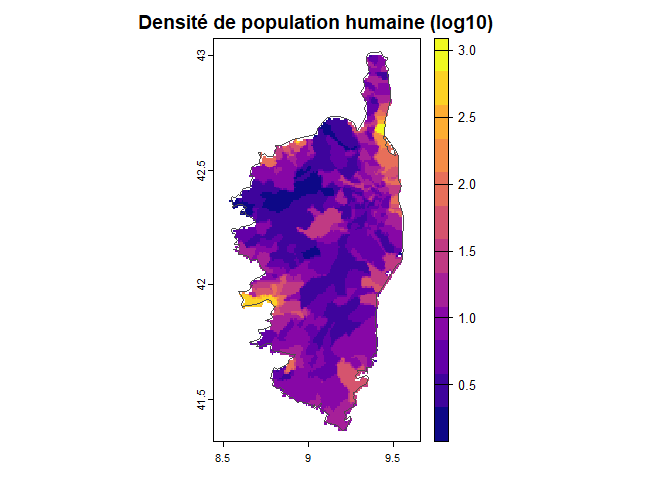

```r
plot(env_corse[["pop_dens_log10"]],
     col = viridis::plasma(12),
     main = "Densité de population humaine (log10)")
plot(st_geometry(fra), add = TRUE,
     border = grey(0.3))
```

# 9. Biais d’échantillonnage

## Description et méta-données

**Téléchargement :** Non disponible en ligne

**Intervalle temporel :** 2000-2023

**Type de données :** raster

**Précision :** 0.008333 * 0.008333°

**Méta-données :**

**Références bibliographiques :**

**Licence :**

**Description des variables :** Il s’agit de variables créées à partir de toutes les occurrences d’un groupe pour servir d’indicateur de la pression d’échantillonnage et donc du biais d’échantillonnage - il s’agit de la méthode “target-group sampling bias”. Nous avons créé une variable de ce type pour les plantes et une autre pour les chiroptères. Pour la générer, toutes les occurrences d’un groupe ont été transformées en raster à la résolution des variables bioclimatiques en appliquant un kernel bi-dimensionnel avec la fonction `kde2d()` du package R `MASS`.

## Illustration des variables

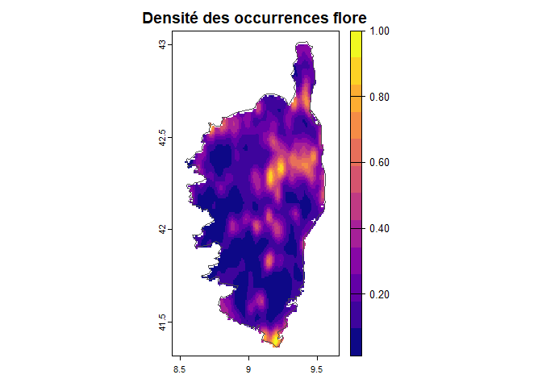

```r
plot(env_corse[["occ_density_cbnc"]],
     col = viridis::plasma(12),
     main = "Densité des occurrences flore")
plot(st_geometry(fra), add = TRUE,
     border = grey(0.3))
```

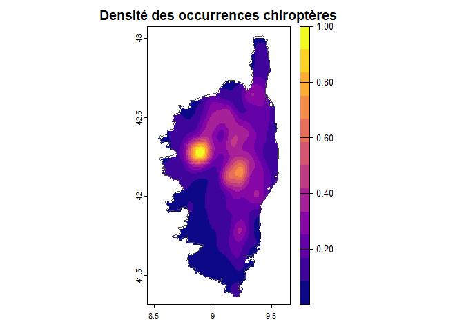

```r
plot(env_corse[["occ_density_chiro"]],
     col = viridis::plasma(12),
     main = "Densité des occurrences chiroptères")
plot(st_geometry(fra), add = TRUE,
     border = grey(0.3))
```

# 10. Pins laricio

## Description et méta-données

Données issues de BD Forêt v2.0

**Téléchargement :** https://geoservices.ign.fr/bdforet

**Intervalle temporel :** 2007-2018

**Type de données :** Vecteur

**Précision :** Variable

**Méta-données :** https://geoservices.ign.fr/documentation/donnees/vecteur/bdforet

**Références bibliographiques :**

**Licence :** Licence ouverte Etalab 2.0

**Description des variables :** Proportion de forêts de pin laricio dans chaque cellule à la résolution des variables climatiques (0.0083333°), en calculant le % d’occupation de chaque maille.

## Illustration des variables

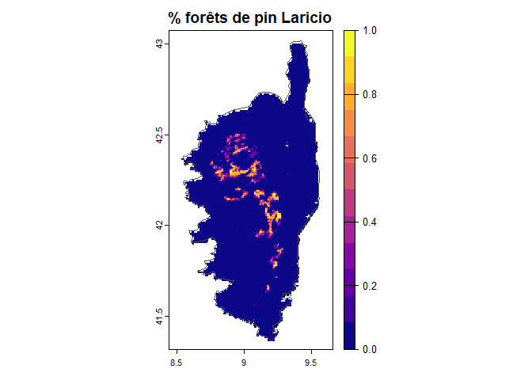

```r
plot(env_corse[["laricio"]],
     col = viridis::plasma(12),
     main = "% forêts de pin Laricio")
plot(st_geometry(fra), add = TRUE,
     border = grey(0.3))
```

# 11. Cavités

## Description et méta-données

**Téléchargement :** https://www.georisques.gouv.fr/donnees/bases-de-donnees/inventaire-des-cavites-souterraines

**Intervalle temporel :** 2010

**Type de données :** vecteur

**Précision :** variable selon les cavités

**Méta-données :** https://www.georisques.gouv.fr/donnees/bases-de-donnees/inventaire-des-cavites-souterraines

**Références bibliographiques :**

**Licence :** Etalab Version 2.0

**Description des variables :** Ce jeu de données a servi à générer une variable de distance aux cavités pour les chiroptères. Les cavités dont les coordonnées étaient imprécises ont été éliminées (coordonnées classées en “centroide de commune” ou “imprécis”). Les cavités ont ensuite été transformées en raster de présence par maille à la résolution des données climatiques (0.0083333°). La distance à la maille la plus proche avec une cavité, en mètres, a ensuite été calculée pour obtenir la variable finale.

## Illustration des variables

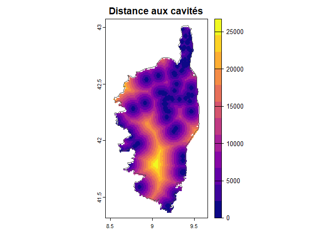

```r
plot(env_corse[["dist_cavites"]],
     col = viridis::plasma(12),
     main = "Distance aux cavités")
plot(st_geometry(fra), add = TRUE,
     border = grey(0.3))
```

# 12. Couche géologique des serpentinites

## Description et méta-données

Bd Charm-50

**Téléchargement :** http://infoterre.brgm.fr/formulaire/telechargement-cartes-geologiques-departementales-150-000-bd-charm-50

**Intervalle temporel :** 2004

**Type de données :** vecteur

**Précision :** 1:50000

**Méta-données :** http://infoterre.brgm.fr/formulaire/telechargement-cartes-geologiques-departementales-150-000-bd-charm-50

**Références bibliographiques :** Janjou, D. Descriptif des cartes géologiques à 1/50 000 format “vecteurs”. BRGM/RP-53473-FR, 2004.

**Licence :** Etalab Version 2.0

**Description des variables :** Seule la couche géologique des serpentinites a été extraites de cette base de données, et elle a été transformée en raster à la résolution des variables climatiques (0.0083333°), en calculant le % d’occupation de chaque maille.

## Illustration des variables

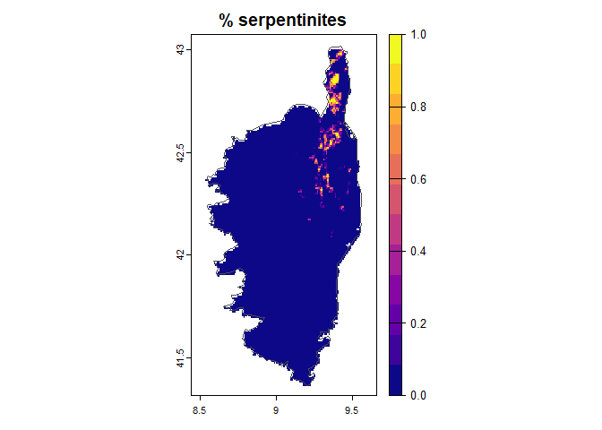

```r
plot(env_corse[["serpentinites"]],
     col = viridis::plasma(12),
     main = "% serpentinites")
plot(st_geometry(fra), add = TRUE,
     border = grey(0.3))
```